# Data Visualisation Project

Seline Uran

Research Questions

These graphs present government survey data on the number of rough sleepers in England to consider the following questions;

Has the number of rough sleepers in England increased over the past decade?

Is the number of sleepers observed equally across England in one year?

Data Origins

The raw data, the number of rough sleepers in England from 2010 - 2020, was retrieved from https://www.gov.uk/government/statistics/rough-sleeping-snapshot-in-england-autumn-2020. This data is gathered by individuals in each local authority conducting either (1) a counts-based estimate (counting visible rough sleepers), (2) an evidence-based estimate that involves meeting with local community partners or (3) an evidence-based estimate that performs counts in a specific area. The measure is carried out on a single night between October 1st and November 30th each year. These measures do not provide an index of homelessness but represents an estimate of individuals sleeping rough (therefore do not include individuals who are ‘sofa surfing’, in temporary accommodation or in a homeless shelter/hostel) on a single night.

Data Preparation

After having removed all sheets from the excel document except for the sheet that contained the total number of rough sleepers I began data preparation.

```r
#importing the raw data
rawdata <- read_excel("rs_statistics.xlsx")
```

The raw data detailed the number of rough sleepers within England and individual counts for each region of England and each Local Authority within each region.

```r
#select the columns required
rs1<- rawdata %>% select(3, 5:15)

#select the rows required
rs1<- rs1 %>% slice(2, 4:11)
```

Finally, I converted the data it into a ‘long’ format for use with ggplot2.

```r
#convert to a 'long' data set
rs1_long <- rs1 %>%
  gather(Year, Number, -Region)
```

The tibble below shows a short section of the data.

```r
#shows the first 16 rows of the dataframe
head(rs1_long, 16)
```

```
## # A tibble: 16 x 3
##    Region                   Year  Number
##    <chr>                    <chr>  <dbl>
##  1 London                   2010     415
##  2 East Midlands            2010     121
##  3 East of England          2010     206
##  4 North East               2010      49
##  5 North West               2010     100
##  6 South East               2010     310
##  7 South West               2010     270
##  8 West Midlands            2010     182
##  9 Yorkshire and The Humber 2010     115
## 10 London                   2011     446
## 11 East Midlands            2011     188
## 12 East of England          2011     242
## 13 North East               2011      32
## 14 North West               2011     149
## 15 South East               2011     430
## 16 South West               2011     337
```

I then prepared the data for the second visualisation. My aim was to create a pie chart of the number of rough sleepers in England by region.

```r
#select rows of interest
rs2<- rawdata %>% slice(2, 4:11)
#select the columns of interest
rs2<- rs2 %>% select (3, 14)

#convert to a 'long' format so that the data can be input to be visualised by ggplot
rs2_long <- rs2 %>%
  gather(Year, Number, -Region)

#displays the first six rows of the tibble
head(rs2_long)
```

```
## # A tibble: 6 x 3
##   Region          Year  Number
##   <chr>           <chr>  <dbl>
## 1 London          2019    1136
## 2 East Midlands   2019     305
## 3 East of England 2019     458
## 4 North East      2019      67
## 5 North West      2019     349
## 6 South East      2019     900
```

Data Visualisation

Graph 1: Number of Rough Sleepers in England by Region (2010 - 2020)

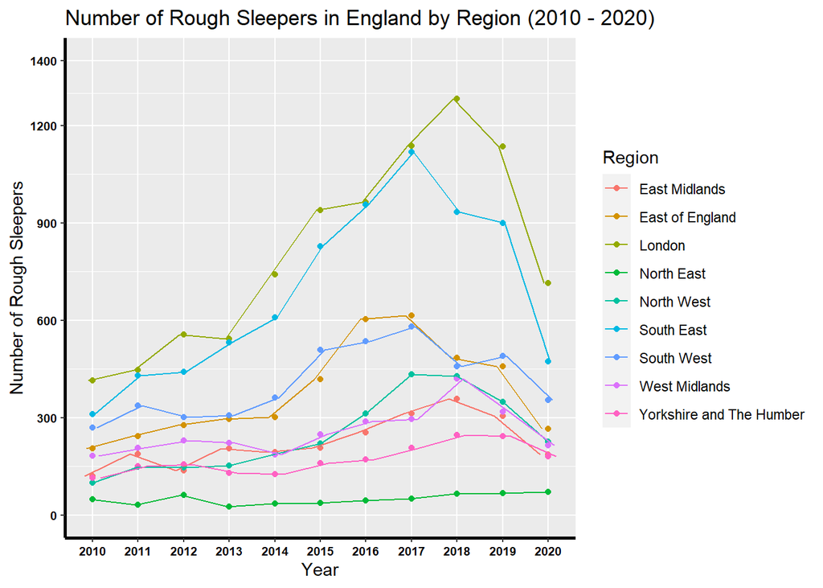

```r
#generate a colour palette with more than 8 colours by extending ggplot palette
nb.cols <- 9
mycolors <- colorRampPalette(brewer.pal(8, "Set2"))(nb.cols)

#generates a line graph with several additional features
rs1plot <-ggplot(rs1_long, aes(x = Year, y = Number, color = Region, group = Region)) +
  geom_point() +
  geom_line(position = position_dodge(0.4)) + #clustered data points are distributed
  scale_fill_manual(values = mycolors) + #a colour scheme is added
  theme(axis.text.x = element_text(face= "bold", color="black",
                                 size=7),
        axis.text.y = element_text(face= "bold", color="black",
                                  size=7),
        axis.line = element_line(colour = "black",
                    size = 1, linetype = "solid")) + #aesthetic of the x/y axis
  labs(title="Number of Rough Sleepers in England by Region (2010 - 2020)",
       x="Year", y = "Number of Rough Sleepers") + #labels the x/y axis and title for plot
  scale_y_continuous(breaks=c(0, 300, 600, 900, 1200, 1400), limits=c(0, 1400)) #adjust the scale

#saves the graph as an image in figs folder
ggsave("figures/rsplot1.png")
```

Graph 2: Percentage of Rough Sleepers in England by Region (2019)

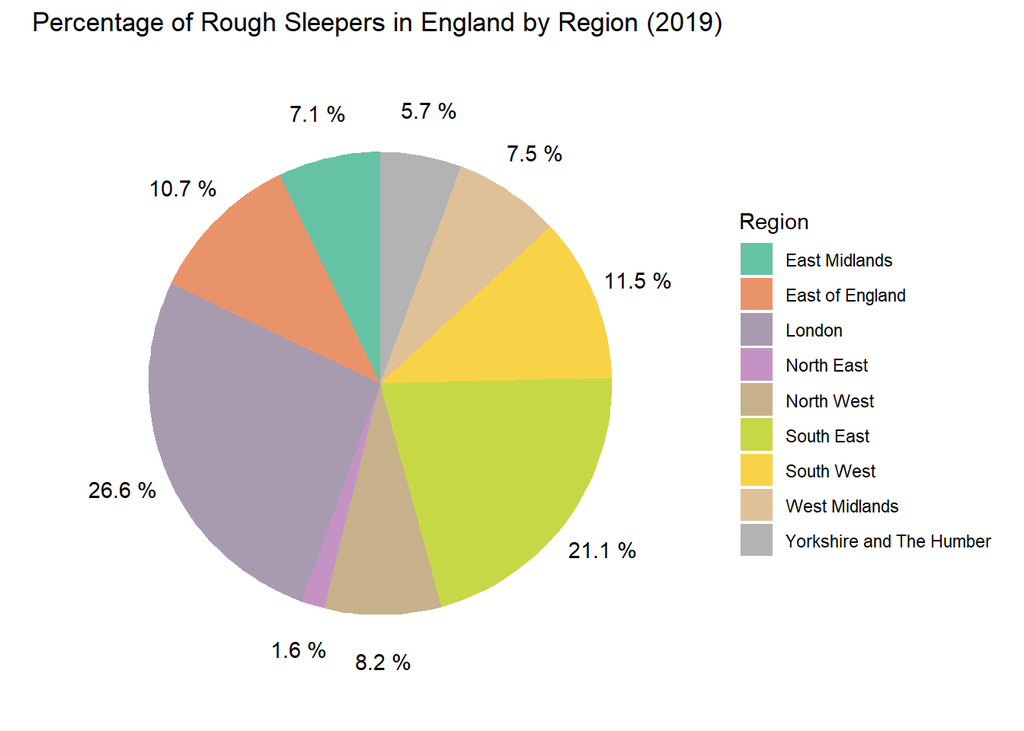

```r
#generate a dataframe of the data
rspie<- data.frame(rs2_long)

#generate a colour palette with more than 8 colours by extending ggplot palette
nb.cols <- 9
mycolors <- colorRampPalette(brewer.pal(8, "Set2"))(nb.cols)

#simple barplot is generated of the dataframe first
bp<- ggplot(rspie, aes(x="", y=Number, fill=Region))+
  geom_bar(width = 1, stat = "identity") +
  geom_text(aes(label = paste(round(Number / sum(Number) * 100, 1), "%"), x = 1.7),
         position = position_stack(vjust = 0.5)) +
  ggtitle("help") +
  theme(axis.text = element_blank(),
        axis.title = element_blank(),
        axis.ticks = element_blank(),
        panel.grid  = element_blank(),
        legend.position="none",
        line = element_blank()) + #blank template theme is added
  scale_fill_manual(values = mycolors) #colour scheme is added matching plot above


#barplot is converted into a piechart
rspiechart <- bp + coord_polar(theta = "y", start=0) +
  theme_void() +
  ggtitle("Percentage of Rough Sleepers in England by Region (2019)")

#saves the graph as an image in figs folder
ggsave("figures/rspiechart.png")
```

Future Directions

A recommendation for improvement on the current visualisation of the data set might be to consider the number of rough sleepers in each region proportional to the population of that region. This would allow for a more accurate comparison across regions of the number of rough sleepers. In addition, the age distribution and composition of gender and ethnicity of rough sleepers in each region were not visualised. These factors might reveal greater insight into the trends within the population of rough sleepers across each region in England and therefore those groups most at risk.